# Practica Calificada 3

Jose Castañeda Chilon, Jose Joselito Carhuaricra Cusipuma, Joaquín Antonio Castañón Vilca

# Descripción

PARTE 1. Indicaciones: • Utilice los datos de “diabetes.xlsx” para responder las siguientes preguntas. • Semilla 66666 • Partición 80%-20% • Variable target: Outcome

1. Ejecute una prueba de hipótesis para probar que la variable “Outcome” está balanceada o no.
2. Calcule la matriz de correlaciones. Interprete. ¿Deben considerarse todas las variables?, ¿Se pueden reducir la dimensionalidad?
3. Presente un análisis exploratorio de los datos. Tablas y gráficos.
4. Ejecute la regresión logística para Outcome con la data training.
5. Presente la matriz de confusión con la data training.
6. ¿Qué variables son significativas? Ejecute la prueba de hipótesis respectiva. Construya intervalos de confianza para los coeficientes de regresión al 97.5%.
7. Interprete los coeficientes de regresión i y de los exp(i)
8. Calcule y presente predicciones para los datos de la hoja “predicción” del archivo “diabetes.xlsx”.
9. Presente la matriz de confusión del ajuste realizado con la data test.
10. Ejecute la regresión logística con los links: probit, cauchit y cloglog. Presente una tabla comparativa de los valores de la residual deviance. Interprete.

# Variables

**Pregnancies** **Glucose** **BloodPressure** **SkinThickness** **Insulin** **BMI** **DiabetesPedigreeFunction** **Age** **Outcome**

# Librerías utilizadas

Las librerías que se van a utilizar para el análisis se presentan a continuación:

```r
library(ggplot2)
library(dplyr)
library(gridExtra)
library(corrplot)
library(readxl)
library(stats)
library(skimr)
library(FSinR)
library(caret)
library(glm2)
library(tidymodels)
library(Rfast)
```

# Lectura de Datos

```r
diabetes <- read_excel('diabetes.xlsx')
diabetes$Outcome <- factor(diabetes$Outcome)
```

# 1. Prueba de hipótesis para probar que la variable “Outcome” está balanceada

se puede usar para probar el nulo de que las proporciones (probabilidades de éxito) en varios grupos son las mismas, o que son iguales a ciertos valores dados:

```r
table(diabetes$Outcome)
```

```
#>
#>   0   1
#> 500 268
```

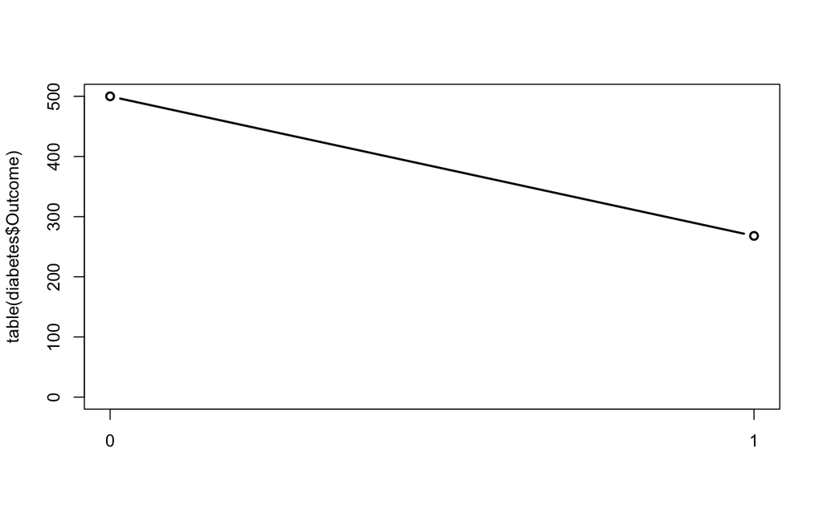

```r
plot(table(diabetes$Outcome), 'bar')
```

```r
prop.test(c(500,268), c(768,768))
```

```
#>
#>  2-sample test for equality of proportions with continuity correction
#>
#> data:  c(500, 268) out of c(768, 768)
#> X-squared = 138.96, df = 1, p-value < 2.2e-16
#> alternative hypothesis: two.sided
#> 95 percent confidence interval:
#>  0.2531081 0.3510585
#> sample estimates:
#>    prop 1    prop 2
#> 0.6510417 0.3489583
```

Como se puede observar la variable respuesta (*Outcome*) esta claramentes desbalanceada ya que tiene 500 valores $0$ y 268 valores $1$, además la prueba de hipotesis aplicada, dió como resultado un valor-p mucho menor a 0.05 por lo que no se puede aceptar la Hipotesis Nula, por lo tanto es de esperar que las proporciones sean diferentes. Concluyendose que esta base de datos se encuentra desbalanceada, lo cual puede afectar en el desarrollo de los modelos más adelante.

# 2. Matriz de Correlaciones

## ¿Deben considerarse todas las variables?, ¿Se pueden reducir la dimensionalidad?

```r
colnames(diabetes)
```

```
#> [1] "Pregnancies"              "Glucose"
#> [3] "BloodPressure"            "SkinThickness"
#> [5] "Insulin"                  "BMI"
#> [7] "DiabetesPedigreeFunction" "Age"
#> [9] "Outcome"
```

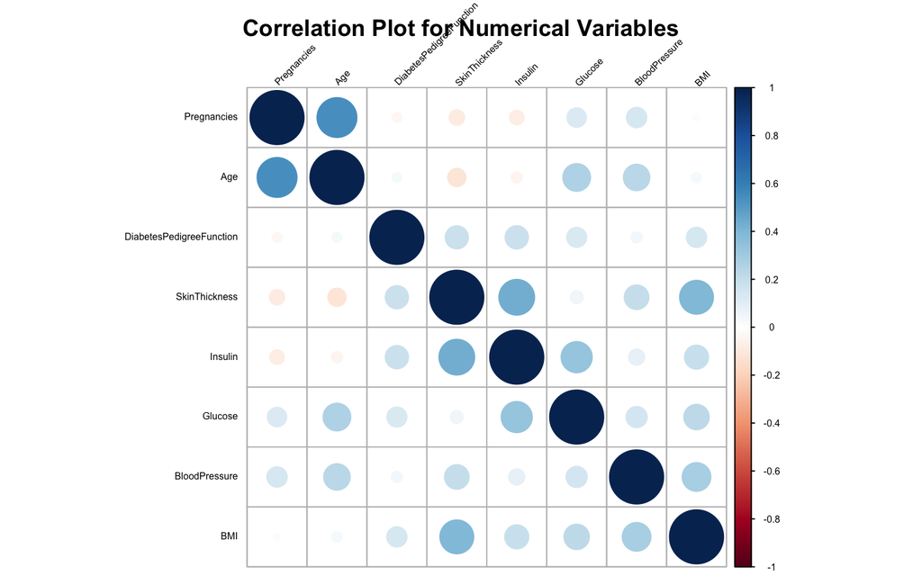

```r
numeric.var <- sapply(diabetes, is.numeric)
corr.matrix <- cor(diabetes[,numeric.var])
corrplot(corr.matrix, main="\n\nCorrelation Plot for Numerical Variables", order = "hclust", tl.col = "black", tl.srt=45, tl.cex=0.5, cl.cex=0.5)
```

```r
colnames(diabetes)
```

```
#> [1] "Pregnancies"              "Glucose"
#> [3] "BloodPressure"            "SkinThickness"
#> [5] "Insulin"                  "BMI"
#> [7] "DiabetesPedigreeFunction" "Age"
#> [9] "Outcome"
```

```r
numeric.var <- sapply(diabetes, is.numeric)
corr.matrix <- cor(diabetes[,numeric.var])
corr.matrix
```

```
#>                          Pregnancies    Glucose BloodPressure SkinThickness
#> Pregnancies               1.00000000 0.12945867    0.14128198   -0.08167177
#> Glucose                   0.12945867 1.00000000    0.15258959    0.05732789
#> BloodPressure             0.14128198 0.15258959    1.00000000    0.20737054
#> SkinThickness            -0.08167177 0.05732789    0.20737054    1.00000000
#> Insulin                  -0.07353461 0.33135711    0.08893338    0.43678257
#> BMI                       0.01768309 0.22107107    0.28180529    0.39257320
#> DiabetesPedigreeFunction -0.03352267 0.13733730    0.04126495    0.18392757
#> Age                       0.54434123 0.26351432    0.23952795   -0.11397026
#>                              Insulin        BMI DiabetesPedigreeFunction
#> Pregnancies              -0.07353461 0.01768309              -0.03352267
#> Glucose                   0.33135711 0.22107107               0.13733730
#> BloodPressure             0.08893338 0.28180529               0.04126495
#> SkinThickness             0.43678257 0.39257320               0.18392757
#> Insulin                   1.00000000 0.19785906               0.18507093
#> BMI                       0.19785906 1.00000000               0.14064695
#> DiabetesPedigreeFunction  0.18507093 0.14064695               1.00000000
#> Age                      -0.04216295 0.03624187               0.03356131
#>                                  Age
#> Pregnancies               0.54434123
#> Glucose                   0.26351432
#> BloodPressure             0.23952795
#> SkinThickness            -0.11397026
#> Insulin                  -0.04216295
#> BMI                       0.03624187
#> DiabetesPedigreeFunction  0.03356131
#> Age                       1.00000000
```

Existe una baja correlación entre las variables, de las cuales las que tienen una correlación de Pearson más fuerte son: Age, Insulin, SkinThickness, BMI y Pregnancies.

Se puede realizar un análisis para la reducción de dimensiones ya que se tienen algunas variables con baja correlación, a continuación se realizará dos test para ver la significancia de cada varaible independiente sobre la varaible respuesta.

```r
set.seed(66666)
algo_search_hill <- searchAlgorithm(searcher = 'hillClimbing')
algo_eval_bina <- filterEvaluator(filter = 'binaryConsistency')
result <- featureSelection(diabetes, 'Outcome', algo_search_hill, algo_eval_bina)
print(cbind(result[c('evaluationMethod', 'searchMethod')]))
```

```
#>                  [,1]
#> evaluationMethod "Binary Consistency"
#> searchMethod     "Hill Climbing"
```

```r
print(result$bestFeatures)
```

```
#>      Pregnancies Glucose BloodPressure SkinThickness Insulin BMI
#> [1,]           1       1             0             1       0   0
#>      DiabetesPedigreeFunction Age
#> [1,]                        0   1
```

Como se puede observar, con la prueba aplicada, se pueden utilziar las variables: *Pregnancies, Glucose, SkinThickness y Age*, como aquellas variables suficientes para realizar una clasificación, es decir, detectar si un paciente tiene diabetes o no.

# 3. Presente un análisis exploratorio de los datos. Tablas y gráficos.

```r
head(diabetes)
```

```
#> # A tibble: 6 x 9
#>   Pregnancies Glucose BloodPressure SkinThickness Insulin   BMI DiabetesPedigre…
#>         <dbl>   <dbl>         <dbl>         <dbl>   <dbl> <dbl>            <dbl>
#> 1           6     148            72            35       0  33.6            0.627
#> 2           1      85            66            29       0  26.6            0.351
#> 3           8     183            64             0       0  23.3            0.672
#> 4           1      89            66            23      94  28.1            0.167
#> 5           0     137            40            35     168  43.1            2.29
#> 6           5     116            74             0       0  25.6            0.201
#> # … with 2 more variables: Age <dbl>, Outcome <fct>
```

```r
dim(diabetes)
```

```
#> [1] 768   9
```

```r
str(diabetes)
```

```
#> tibble [768 × 9] (S3: tbl_df/tbl/data.frame)
#>  $ Pregnancies             : num [1:768] 6 1 8 1 0 5 3 10 2 8 ...
#>  $ Glucose                 : num [1:768] 148 85 183 89 137 116 78 115 197 125 ...
#>  $ BloodPressure           : num [1:768] 72 66 64 66 40 74 50 0 70 96 ...
#>  $ SkinThickness           : num [1:768] 35 29 0 23 35 0 32 0 45 0 ...
#>  $ Insulin                 : num [1:768] 0 0 0 94 168 0 88 0 543 0 ...
#>  $ BMI                     : num [1:768] 33.6 26.6 23.3 28.1 43.1 25.6 31 35.3 30.5 0 ...
#>  $ DiabetesPedigreeFunction: num [1:768] 0.627 0.351 0.672 0.167 2.288 ...
#>  $ Age                     : num [1:768] 50 31 32 21 33 30 26 29 53 54 ...
#>  $ Outcome                 : Factor w/ 2 levels "0","1": 2 1 2 1 2 1 2 1 2 2 ...
```

```r
skim(diabetes)
```

Data summary

| Name | diabetes |
| --- | --- |
| Number of rows | 768 |
| Number of columns | 9 |
| _______________________ |  |
| Column type frequency: |  |
| factor | 1 |
| numeric | 8 |
| ________________________ |  |
| Group variables | None |

**Variable type: factor**

| skim_variable | n_missing | complete_rate | ordered | n_unique | top_counts |
| --- | --- | --- | --- | --- | --- |
| Outcome | 0 | 1 | FALSE | 2 | 0: 500, 1: 268 |

**Variable type: numeric**

| skim_variable | n_missing | complete_rate | mean | sd | p0 | p25 | p50 | p75 | p100 | hist |
| --- | --- | --- | --- | --- | --- | --- | --- | --- | --- | --- |
| Pregnancies | 0 | 1 | 3.85 | 3.37 | 0.00 | 1.00 | 3.00 | 6.00 | 17.00 | ▇▃▂▁▁ |
| Glucose | 0 | 1 | 120.89 | 31.97 | 0.00 | 99.00 | 117.00 | 140.25 | 199.00 | ▁▁▇▆▂ |
| BloodPressure | 0 | 1 | 69.11 | 19.36 | 0.00 | 62.00 | 72.00 | 80.00 | 122.00 | ▁▁▇▇▁ |
| SkinThickness | 0 | 1 | 20.54 | 15.95 | 0.00 | 0.00 | 23.00 | 32.00 | 99.00 | ▇▇▂▁▁ |
| Insulin | 0 | 1 | 79.80 | 115.24 | 0.00 | 0.00 | 30.50 | 127.25 | 846.00 | ▇▁▁▁▁ |
| BMI | 0 | 1 | 31.99 | 7.88 | 0.00 | 27.30 | 32.00 | 36.60 | 67.10 | ▁▃▇▂▁ |
| DiabetesPedigreeFunction | 0 | 1 | 0.47 | 0.33 | 0.08 | 0.24 | 0.37 | 0.63 | 2.42 | ▇▃▁▁▁ |
| Age | 0 | 1 | 33.24 | 11.76 | 21.00 | 24.00 | 29.00 | 41.00 | 81.00 | ▇▃▁▁▁ |

```r
cat("Valores nulos en la base de datos:", sum(is.na(diabetes)), "\n")
```

```
#> Valores nulos en la base de datos: 0
```

```r
summary(diabetes)
```

```
#>   Pregnancies        Glucose      BloodPressure    SkinThickness
#>  Min.   : 0.000   Min.   :  0.0   Min.   :  0.00   Min.   : 0.00
#>  1st Qu.: 1.000   1st Qu.: 99.0   1st Qu.: 62.00   1st Qu.: 0.00
#>  Median : 3.000   Median :117.0   Median : 72.00   Median :23.00
#>  Mean   : 3.845   Mean   :120.9   Mean   : 69.11   Mean   :20.54
#>  3rd Qu.: 6.000   3rd Qu.:140.2   3rd Qu.: 80.00   3rd Qu.:32.00
#>  Max.   :17.000   Max.   :199.0   Max.   :122.00   Max.   :99.00
#>     Insulin           BMI        DiabetesPedigreeFunction      Age
#>  Min.   :  0.0   Min.   : 0.00   Min.   :0.0780           Min.   :21.00
#>  1st Qu.:  0.0   1st Qu.:27.30   1st Qu.:0.2437           1st Qu.:24.00
#>  Median : 30.5   Median :32.00   Median :0.3725           Median :29.00
#>  Mean   : 79.8   Mean   :31.99   Mean   :0.4719           Mean   :33.24
#>  3rd Qu.:127.2   3rd Qu.:36.60   3rd Qu.:0.6262           3rd Qu.:41.00
#>  Max.   :846.0   Max.   :67.10   Max.   :2.4200           Max.   :81.00
#>  Outcome
#>  0:500
#>  1:268
#>
#>
#>
#>
```

```r
summary(diabetes)
```

```
#>   Pregnancies        Glucose      BloodPressure    SkinThickness
#>  Min.   : 0.000   Min.   :  0.0   Min.   :  0.00   Min.   : 0.00
#>  1st Qu.: 1.000   1st Qu.: 99.0   1st Qu.: 62.00   1st Qu.: 0.00
#>  Median : 3.000   Median :117.0   Median : 72.00   Median :23.00
#>  Mean   : 3.845   Mean   :120.9   Mean   : 69.11   Mean   :20.54
#>  3rd Qu.: 6.000   3rd Qu.:140.2   3rd Qu.: 80.00   3rd Qu.:32.00
#>  Max.   :17.000   Max.   :199.0   Max.   :122.00   Max.   :99.00
#>     Insulin           BMI        DiabetesPedigreeFunction      Age
#>  Min.   :  0.0   Min.   : 0.00   Min.   :0.0780           Min.   :21.00
#>  1st Qu.:  0.0   1st Qu.:27.30   1st Qu.:0.2437           1st Qu.:24.00
#>  Median : 30.5   Median :32.00   Median :0.3725           Median :29.00
#>  Mean   : 79.8   Mean   :31.99   Mean   :0.4719           Mean   :33.24
#>  3rd Qu.:127.2   3rd Qu.:36.60   3rd Qu.:0.6262           3rd Qu.:41.00
#>  Max.   :846.0   Max.   :67.10   Max.   :2.4200           Max.   :81.00
#>  Outcome
#>  0:500
#>  1:268
#>
#>
#>
#>
```

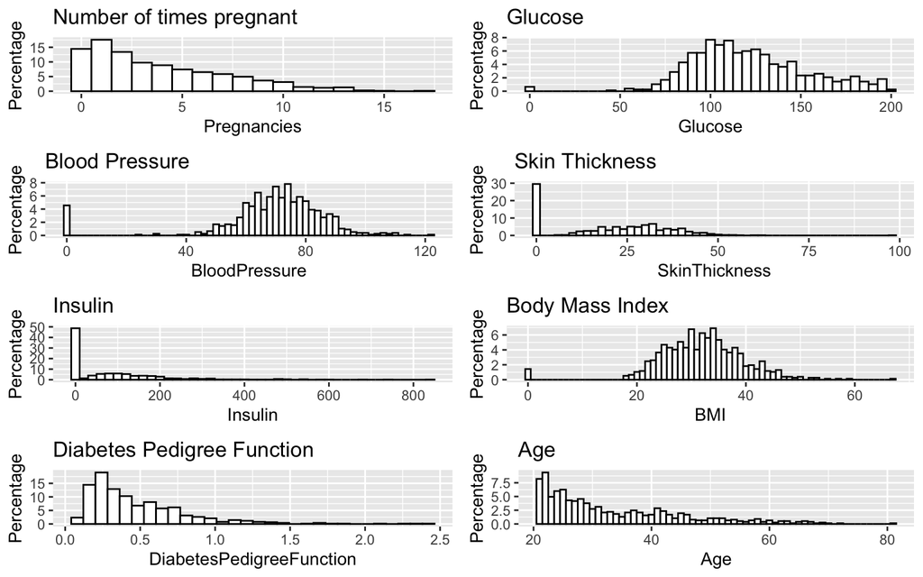

```r
p1 <- ggplot(diabetes, aes(x=Pregnancies)) + ggtitle("Number of times pregnant") +
  geom_histogram(aes(y = 100*(..count..)/sum(..count..)), binwidth = 1, colour="black", fill="white") + ylab("Percentage")
p2 <- ggplot(diabetes, aes(x=Glucose)) + ggtitle("Glucose") +
  geom_histogram(aes(y = 100*(..count..)/sum(..count..)), binwidth = 5, colour="black", fill="white") + ylab("Percentage")
p3 <- ggplot(diabetes, aes(x=BloodPressure)) + ggtitle("Blood Pressure") +
  geom_histogram(aes(y = 100*(..count..)/sum(..count..)), binwidth = 2, colour="black", fill="white") + ylab("Percentage")
p4 <- ggplot(diabetes, aes(x=SkinThickness)) + ggtitle("Skin Thickness") +
  geom_histogram(aes(y = 100*(..count..)/sum(..count..)), binwidth = 2, colour="black", fill="white") + ylab("Percentage")
p5 <- ggplot(diabetes, aes(x=Insulin)) + ggtitle("Insulin") +
  geom_histogram(aes(y = 100*(..count..)/sum(..count..)), binwidth = 20, colour="black", fill="white") + ylab("Percentage")
p6 <- ggplot(diabetes, aes(x=BMI)) + ggtitle("Body Mass Index") +
  geom_histogram(aes(y = 100*(..count..)/sum(..count..)), binwidth = 1, colour="black", fill="white") + ylab("Percentage")
p7 <- ggplot(diabetes, aes(x=DiabetesPedigreeFunction)) + ggtitle("Diabetes Pedigree Function") +
  geom_histogram(aes(y = 100*(..count..)/sum(..count..)), colour="black", fill="white") + ylab("Percentage")
p8 <- ggplot(diabetes, aes(x=Age)) + ggtitle("Age") +
  geom_histogram(aes(y = 100*(..count..)/sum(..count..)), binwidth=1, colour="black", fill="white") + ylab("Percentage")
grid.arrange(p1, p2, p3, p4, p5, p6, p7, p8, ncol=2)
```

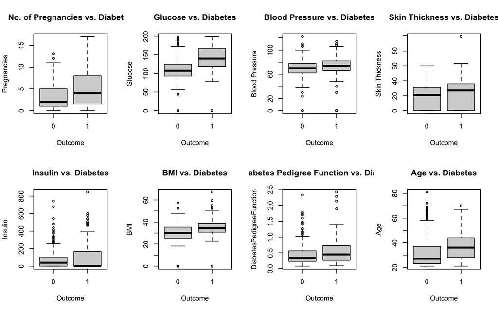

```r
attach(diabetes)
par(mfrow=c(2,4))
boxplot(Pregnancies~Outcome, main="No. of Pregnancies vs. Diabetes",
        xlab="Outcome", ylab="Pregnancies")
boxplot(Glucose~Outcome, main="Glucose vs. Diabetes",
        xlab="Outcome", ylab="Glucose")
boxplot(BloodPressure~Outcome, main="Blood Pressure vs. Diabetes",
        xlab="Outcome", ylab="Blood Pressure")
boxplot(SkinThickness~Outcome, main="Skin Thickness vs. Diabetes",
        xlab="Outcome", ylab="Skin Thickness")
boxplot(Insulin~Outcome, main="Insulin vs. Diabetes",
        xlab="Outcome", ylab="Insulin")
boxplot(BMI~Outcome, main="BMI vs. Diabetes",
        xlab="Outcome", ylab="BMI")
boxplot(DiabetesPedigreeFunction~Outcome, main="Diabetes Pedigree Function vs. Diabetes", xlab="Outcome", ylab="DiabetesPedigreeFunction")
boxplot(Age~Outcome, main="Age vs. Diabetes",
        xlab="Outcome", ylab="Age")
par(mfrow=c(1,1))
```